# Variability and Uncertainty

Interactive workshop

## About me

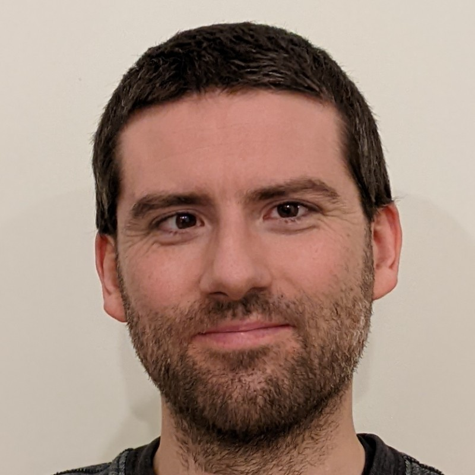

- Ruben Faelens
  - Belgian, living in Leuven
  - ruben.faelens@gmail.com
- Computer Scientist, graduated 2010
- PK/PD modeling & simulation from 2012 onward
- Wrote *simulo*, a clinical trial simulation software
- Consultant for pharma industry from 2014 - 2018
- PhD in precision dosing from 2017 - 2022
- Working at J&J since Feb 2022

## Conflict of interest

The views and opinions expressed in this course are those of the speakers and do not necessarily reflect the views or positions of their employers.

The lecturer declares no conflict of interest.

## Learning objectives

- Understand the role of variability and uncertainty in pharmacomtric modeling & simulation

## References

- Meeker et al, Statistical intervals: a guide for practitioners and researchers. 2017
- Kummel et al, Confidence and prediction intervals for pharmacometric models. CPT: PSP, 2018
- Chuanpu, Variability and uncertainty: interpretation and usage of pharmacometric simulations and intervals. Journal of Pharmacokinetics and pharmacodynamics, 2022

## Contents

- Theoretical introduction
- Case 1: Concentration-QT
- Case 2: inhibition of a receptor
- Case 3: bio-equivalence
- Permissible shortcuts

## Theoretical introduction: a population

- A *population* is the entire group of individuals, objects, or elements that a researcher is interested in studying.
- *Variability* tells you how far apart data points lie from each other and from the center of a distribution in the population.
- A *sample* is a (representative) subset of the population.
- An *estimand* is the population measure we are interested in describing (e.g. population mean).
- *Uncertainty* is how far we can expect an estimate to be from the truth, based on a sample from the population.
- More observed data reduces uncertainty, but not variability.
- With limited sample size, variability drives uncertainty.
- A *95% confidence interval* covers the true value of the parameter 95% of the time (i.e. in many repeats of the same experiment) ** This reflects uncertainty
- A *95% prediction interval* covers *future observations sampled from the population* 95% of the time ** This reflects uncertainty and variability

## Pragmatic definitions

- A clinical trial is a sample of the population and is used to build a model describing the compound and disease (PK/PD)
- The model is used to infer on the *overall population* ** Decisions: Dose, dose adaptation for intrinsic/extrinsic factors, target indication ** Predictions include PK, PD, efficacy / responder rate, safety / AE rates
- The model is used to infer about *future clinical trials* ** Decisions: Sample size, endpoint, inclusion / exclusion criteria ** Predictions: study power, likely outcomes, detectable drug effect size

## Case study 1 | Concentration-QT

> The upper bound of the two-sided 90% confidence interval for model-derived ddQTc should be <10 ms at the highest clinically relevant exposure.

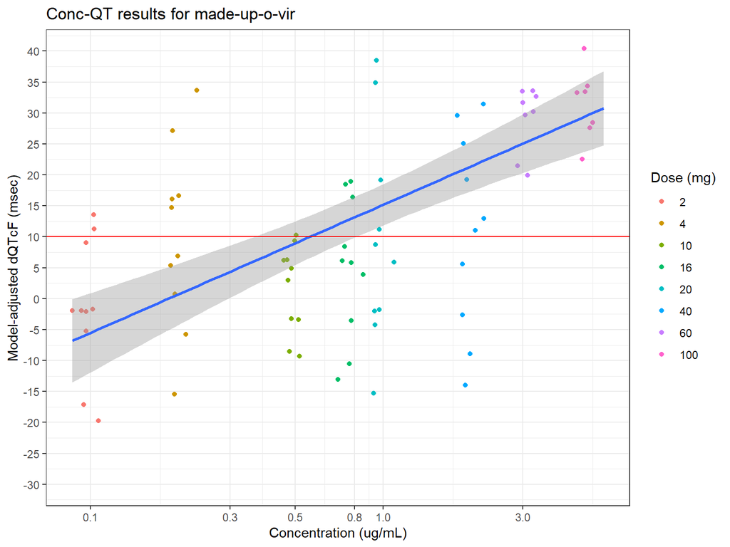

- What does the grey area show: 95% PI or 95% CI?
- Does this model fit the data?
- Is the model *fit for purpose*?
- Suppose the highest *made-up-o-vir* concentration expected in Phase 2 is 0.3 ug/mL. Would you recommend expanded ECG monitoring?

## Case study 2 | Inhibition of a receptor

Our compound is designed to bind to a receptor, thereby inhibiting its function.

We have tested in vitro using cell cultures (N=3 per dose), measuring occupation using an immunofluorescent antibody that sticks to the receptor, as well as concentration within the cell. *What concentration target do you recommend to achieve 90% inhibition?*

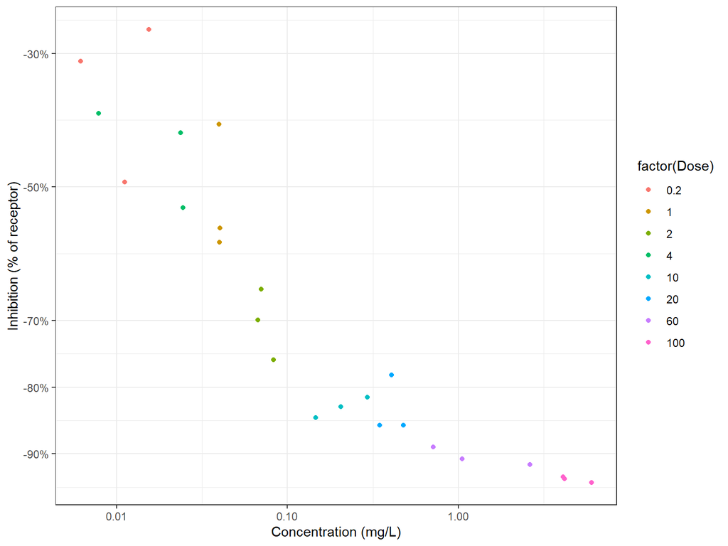

## Case study 2 | Can we fit a model?

```
##
## Formula: Inhib ~ 1/(1 + EMax * Conc/(EC50 + Conc))
##
## Parameters:
##      Estimate Std. Error t value Pr(>|t|)
## EMax  9.65000    2.92604   3.298  0.00328 **
## EC50  0.22210    0.08485   2.618  0.01572 *
## ---
## Signif. codes:  0 '***' 0.001 '**' 0.01 '*' 0.05 '.' 0.1 ' ' 1
##
## Residual standard error: 0.0792 on 22 degrees of freedom
##
## Number of iterations to convergence: 10
## Achieved convergence tolerance: 4.005e-06
```

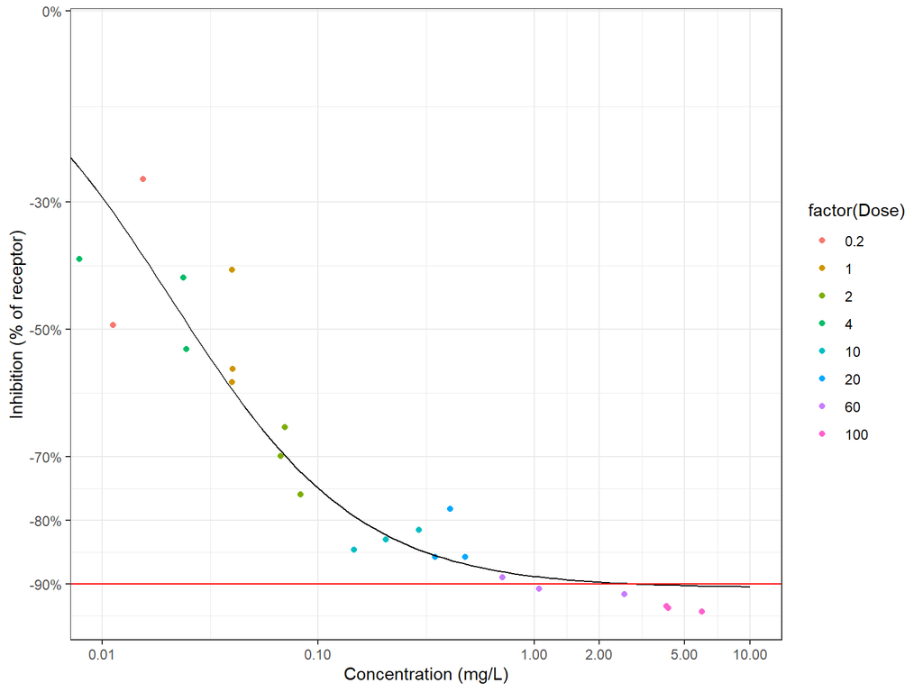

*What concentration target do you recommend to achieve 90% inhibition?*

## Case study 2 | Never trust a single line…

[output not shown]

[output not shown]

[output not shown]

[output not shown]

[output not shown]

[output not shown]

[output not shown]

[output not shown]

[output not shown]

[output not shown]

[output not shown]

[output not shown]

[output not shown]

[output not shown]

[output not shown]

[output not shown]

[output not shown]

[output not shown]

[output not shown]

[output not shown]

[output not shown]

[output not shown]

[output not shown]

[output not shown]

[output not shown]

[output not shown]

[output not shown]

[output not shown]

[output not shown]

[output not shown]

[output not shown]

[output not shown]

[output not shown]

[output not shown]

[output not shown]

[output not shown]

[output not shown]

[output not shown]

[output not shown]

[output not shown]

[output not shown]

[output not shown]

[output not shown]

[output not shown]

[output not shown]

[output not shown]

[output not shown]

[output not shown]

[output not shown]

[output not shown]

[output not shown]

[output not shown]

[output not shown]

[output not shown]

[output not shown]

[output not shown]

[output not shown]

[output not shown]

[output not shown]

[output not shown]

[output not shown]

[output not shown]

[output not shown]

[output not shown]

[output not shown]

[output not shown]

[output not shown]

[output not shown]

[output not shown]

[output not shown]

[output not shown]

[output not shown]

[output not shown]

[output not shown]

[output not shown]

[output not shown]

[output not shown]

[output not shown]

[output not shown]

[output not shown]

[output not shown]

[output not shown]

[output not shown]

[output not shown]

[output not shown]

[output not shown]

[output not shown]

[output not shown]

[output not shown]

[output not shown]

[output not shown]

[output not shown]

[output not shown]

[output not shown]

[output not shown]

[output not shown]

[output not shown]

[output not shown]

[output not shown]

[output not shown]

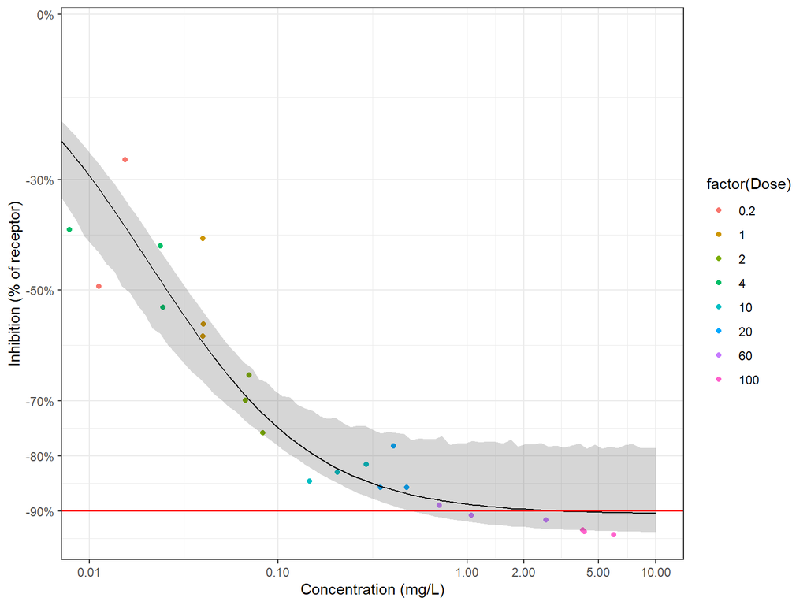

*What concentration target do you recommend to achieve 90% inhibition?*

## Case study 3 | Bio-equivalence

> In studies to determine bioequivalence after a single dose, the parameters to be analysed are AUC(0-t) [..] and Cmax. For these parameters the 90% confidence interval for the ratio of the test and reference products should be contained within the acceptance interval of 80.00-125.00%.

Arm 1: Formulation A, 50mg single bolus, 12 healthy volunteers Arm 2: Formulation B, 50mg single bolus, 12 healthy volunteers

```
## Building model_cpp ... done.
```

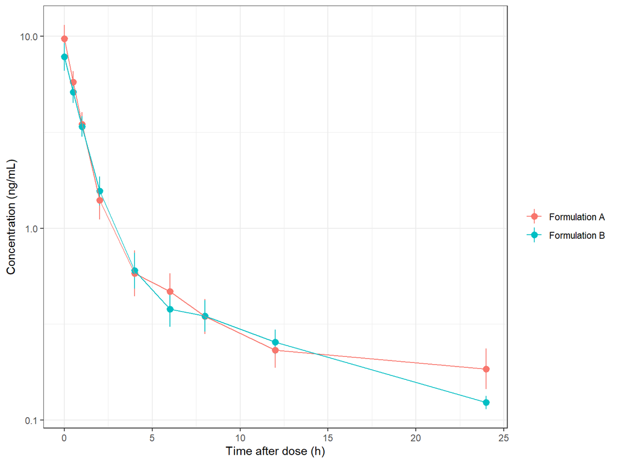

```
## Setting up options
```

```
## No dose information provided, calculations requiring dose will return NA.
```

```
## Starting dense PK NCA calculations.
```

```
## Combining completed dense PK calculation results.
```

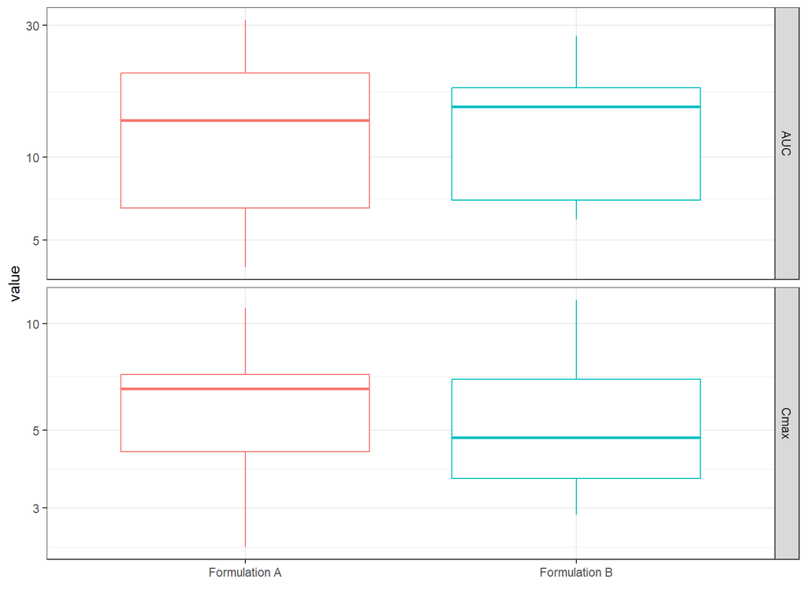

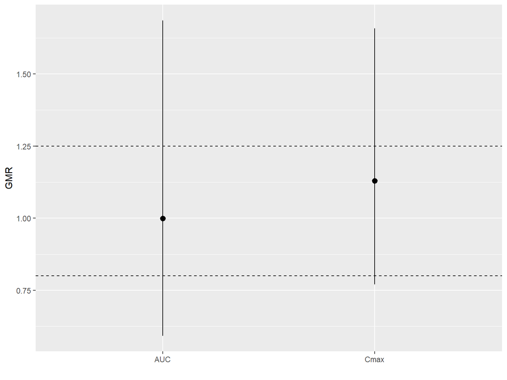

## Case study 3b | design of bio-equivalence trial

```
## No dose information provided, calculations requiring dose will return NA.
```

[output not shown]

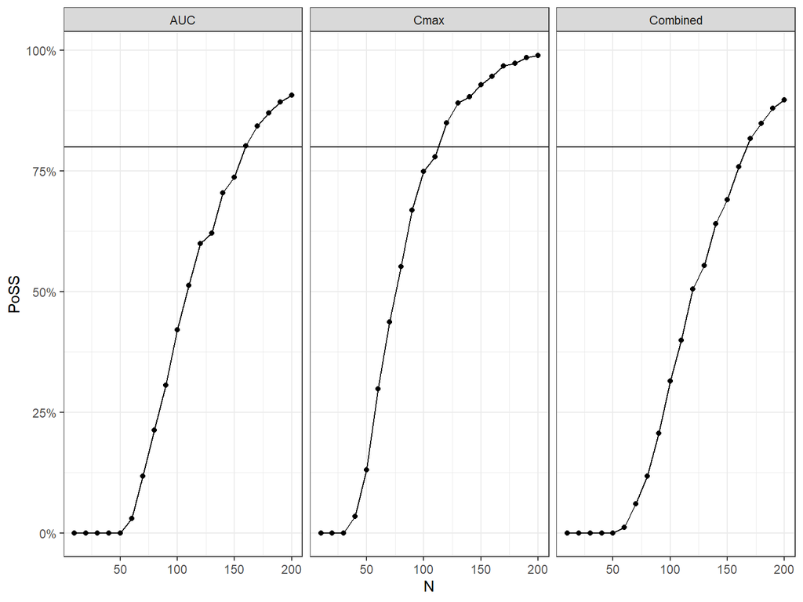

## Case study 3b | Sampling variability?

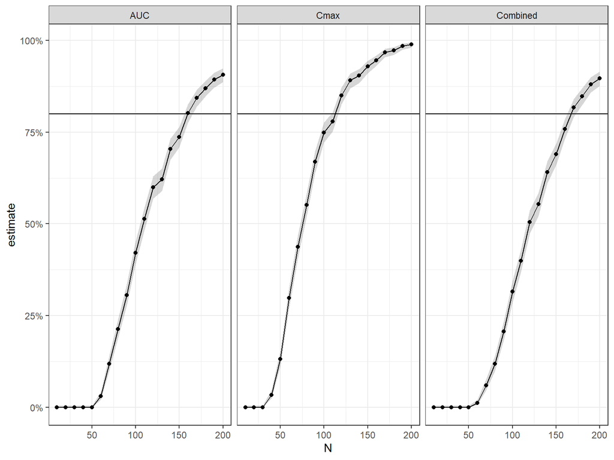

- Simulation appropriateness metric.
- Shows uncertainty in your simulated summary statistic. *This approaches 0 as you simulate infinite samples*.

## Case study 3b | what about uncertainty?

The bio-availability of our new formulation may be 5% lower as compared to the originator. This may result in higher or lower concentrations. How does this uncertainty affect our power and required sample size??

[output not shown]

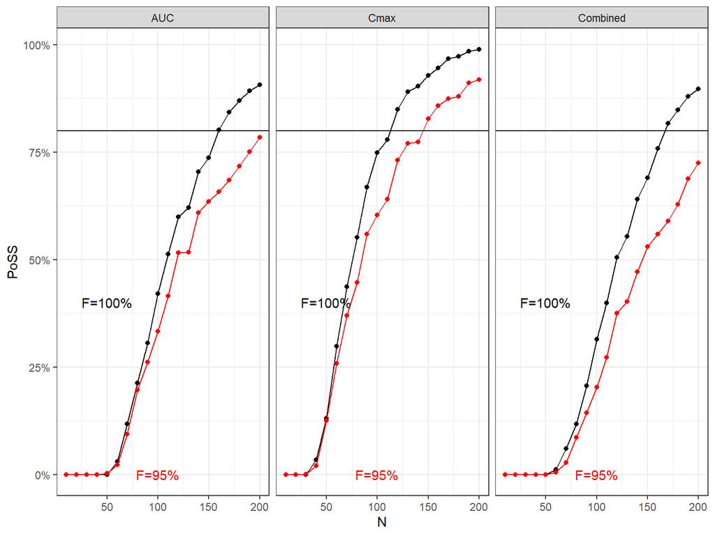

# Allowable shortcuts in pharmacometric simulation

- PK generally well described by end of Ph1. RSEs low. Largest driver for 95% PI is *variability*. Parameter uncertainty may be ignored, except for rare covariate effects.
- PD well described by end of Ph2. Largest driver for 95% PI is still *variability*. Parameter uncertainty may be ignored.
- ER typically describes population summary statistics only (e.g. response rate). 95% PI is primarily determined by *uncertainty on parameter estimates*.
- Disregard uncertainty when variability is 1) well characterized, and 2) variability is much larger than uncertainty

# What intervals are shown on a VPC?

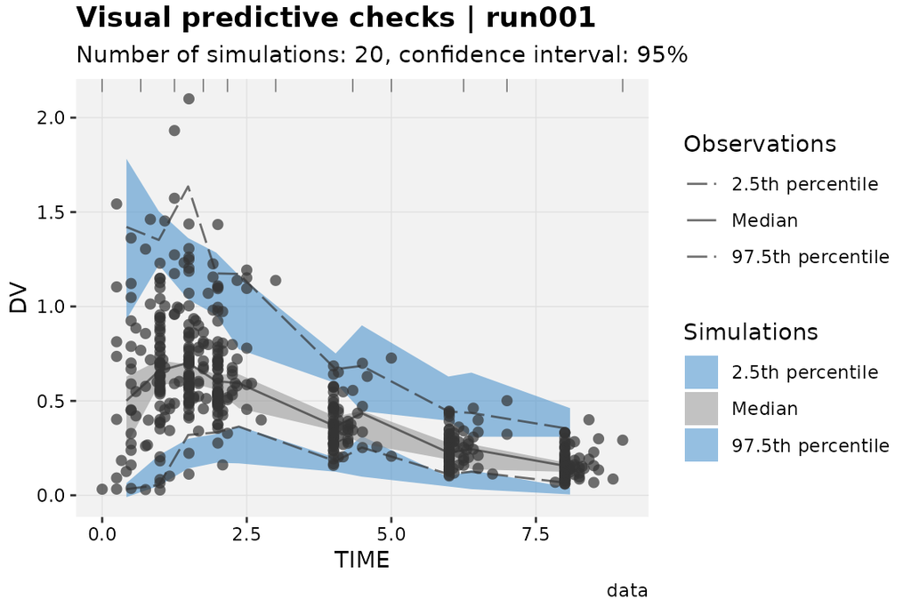

# Conclusion

- Variability and uncertainty are important concepts in pharmacometrics
- Incorporate these concepts in all decision making
- You may be able to simplify where appropriate.
- You can use the term 95% PI.